# Homework 3

Jintao Liu

April 2, 2018

```r
knitr::opts_chunk$set(echo = TRUE,warning=FALSE,message=FALSE)

library(MASS); library(splines)

library(boot);library(tidyverse)
```

# 1 Chapter 7

## 1.1 Question 9

### 1.1.1 (a)

```r
cubic <- lm(nox~poly(dis,3),data=Boston)
summary(cubic)
```

```
##
## Call:
## lm(formula = nox ~ poly(dis, 3), data = Boston)
##
## Residuals:
##       Min        1Q    Median        3Q       Max
## -0.121130 -0.040619 -0.009738  0.023385  0.194904
##
## Coefficients:
##                Estimate Std. Error t value Pr(>|t|)
## (Intercept)    0.554695   0.002759 201.021  < 2e-16 ***
## poly(dis, 3)1 -2.003096   0.062071 -32.271  < 2e-16 ***
## poly(dis, 3)2  0.856330   0.062071  13.796  < 2e-16 ***
## poly(dis, 3)3 -0.318049   0.062071  -5.124 4.27e-07 ***
## ---
## Signif. codes:  0 '***' 0.001 '**' 0.01 '*' 0.05 '.' 0.1 ' ' 1
##
## Residual standard error: 0.06207 on 502 degrees of freedom
## Multiple R-squared:  0.7148, Adjusted R-squared:  0.7131
## F-statistic: 419.3 on 3 and 502 DF,  p-value: < 2.2e-16
```

```r
par(mfrow=c(2,2))
#plot(cubic)

cubic <- lm(nox~poly(dis,3, raw =T),data=Boston)
summary(cubic)
```

```
##
## Call:
## lm(formula = nox ~ poly(dis, 3, raw = T), data = Boston)
##
## Residuals:
##       Min        1Q    Median        3Q       Max
## -0.121130 -0.040619 -0.009738  0.023385  0.194904
##
## Coefficients:
##                          Estimate Std. Error t value Pr(>|t|)
## (Intercept)             0.9341281  0.0207076  45.110  < 2e-16 ***
## poly(dis, 3, raw = T)1 -0.1820817  0.0146973 -12.389  < 2e-16 ***
## poly(dis, 3, raw = T)2  0.0219277  0.0029329   7.476 3.43e-13 ***
## poly(dis, 3, raw = T)3 -0.0008850  0.0001727  -5.124 4.27e-07 ***
## ---
## Signif. codes:  0 '***' 0.001 '**' 0.01 '*' 0.05 '.' 0.1 ' ' 1
##
## Residual standard error: 0.06207 on 502 degrees of freedom
## Multiple R-squared:  0.7148, Adjusted R-squared:  0.7131
## F-statistic: 419.3 on 3 and 502 DF,  p-value: < 2.2e-16
```

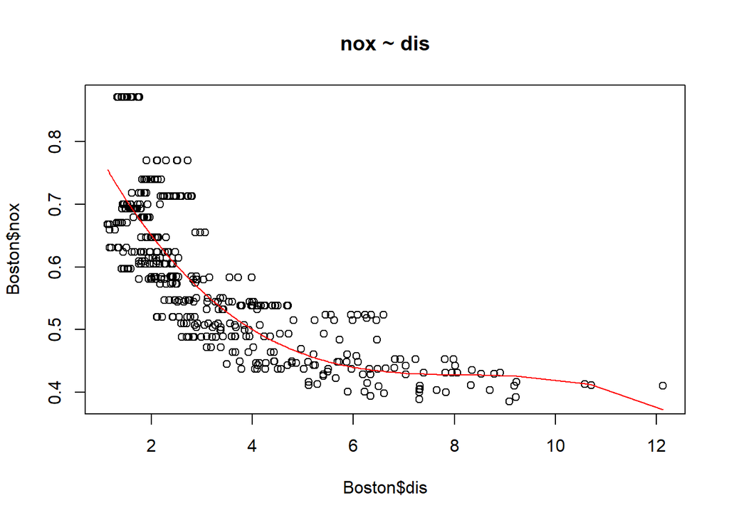

```r
plot(Boston$dis,Boston$nox, main="nox ~ dis")
idx <- order(Boston$dis)
points(Boston$dis[idx], fitted(cubic)[idx], type='l', col=2, lwd=1)
```

A scatter plot with a fitted line indicates a good model fit.

### 1.1.2 (b)

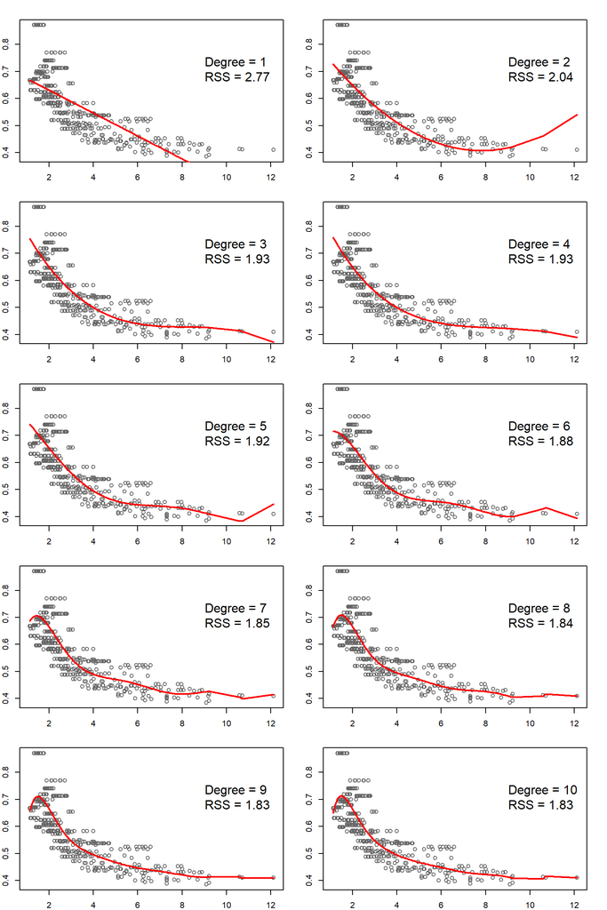

```r
attach(Boston)
par(mfrow=c(5,2))
par(mar=c(2,2,2,2))
for(i in 1:10){
  fit <- lm(nox ~ poly(dis ,i))
  preds <- predict(fit, newdata =Boston, se=TRUE)
  plot(dis,nox, col="grey40", xlab="dis", ylab="nox")
  legend(8,0.8,paste("Degree = ", i, "\n", "RSS = ",sep="", round(sum(fit$residuals^2),2)),bty="n",cex=1.5)
  points(dis[idx], fitted(fit)[idx], type='l', col=2, lwd=2)
}
```

```r
detach(Boston)
```

### 1.1.3 (c)

```r
set.seed(666)
degree <- 1:10
cv.error <- rep(NA,10)
for (i in degree){
    fit <- glm(nox ~ poly(dis ,i),data=Boston)
    cv.error[i] = cv.glm(Boston,fit, K=10)$delta[1]
}
cv.error
```

```
##  [1] 0.005527745 0.004054299 0.003922819 0.003893007 0.004166049
##  [6] 0.005342858 0.009582706 0.009239157 0.006884391 0.005537674
```

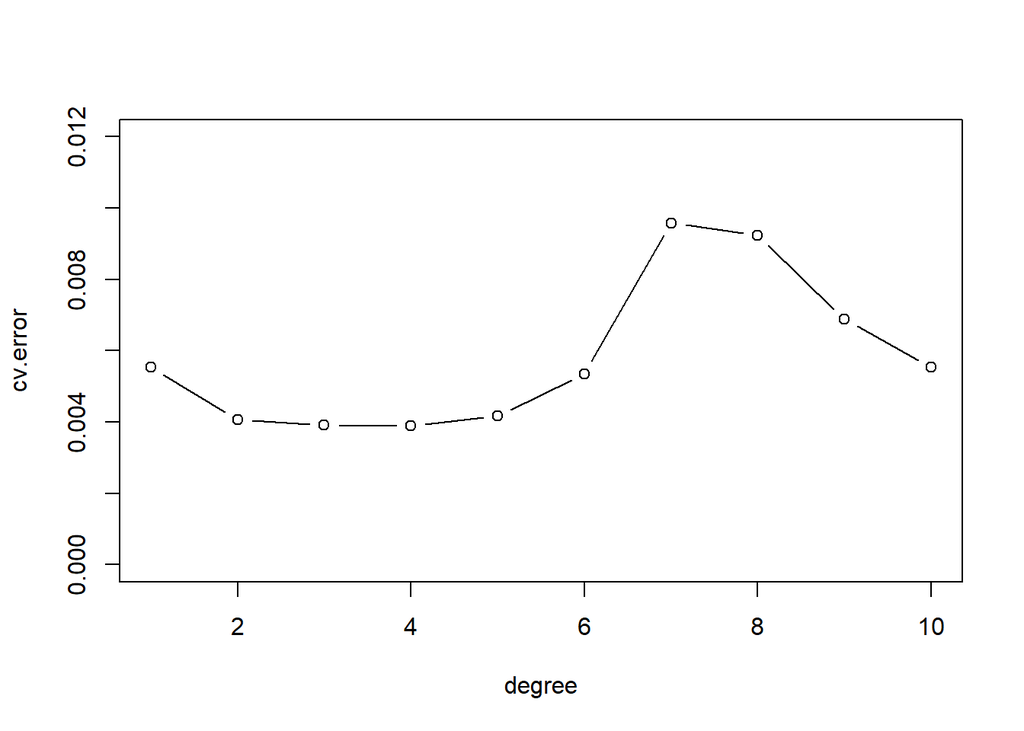

```r
plot(degree,cv.error,type="b", ylim = c(0, 0.012))
```

Looks like the 3rd and 4th degree have equally lowest CV error. After 5th degree, the CV error starts to fluctuate and becomes unstable. We can repeat this step 10 times to see the variation of the CV error.

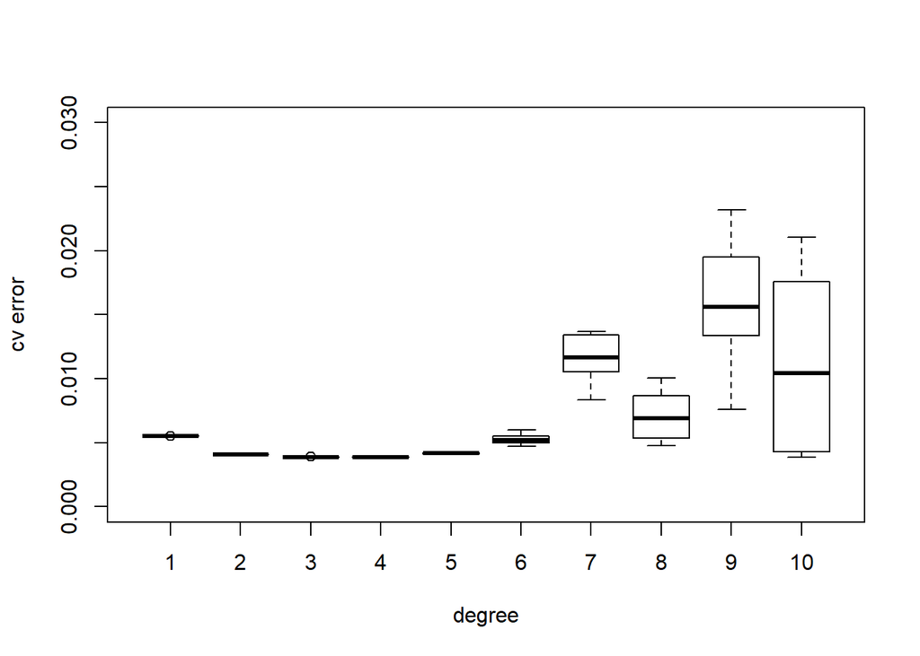

```r
cv.error10 <- matrix(NA,nrow=10, ncol=10)
for(i in 1:10){
  set.seed(i)
  for (j in degree){
      fit <- glm(nox ~ poly(dis ,j),data=Boston)
      cv.error10[i,j] <- cv.glm(Boston,fit, K=10)$delta[1]
  }
}
boxplot(cv.error10,ylim=c(0,0.03),xlab="degree", ylab="cv error")
```

```r
# Look at the mean of cv error the each degree
colMeans(cv.error10)
```

```
##  [1] 0.005526181 0.004082282 0.003873801 0.003887038 0.004173475
##  [6] 0.005271818 0.011528008 0.006945973 0.018566623 0.013526087
```

Finally it turns out that the third degree (cubic spline) is the best choice according to cross-validation.

### 1.1.4 (d)

```r
attach(Boston)
bs.fit<-lm(nox~ bs(dis,df = 4))
summary(bs.fit)
```

```
##
## Call:
## lm(formula = nox ~ bs(dis, df = 4))
##
## Residuals:
##       Min        1Q    Median        3Q       Max
## -0.124622 -0.039259 -0.008514  0.020850  0.193891
##
## Coefficients:
##                  Estimate Std. Error t value Pr(>|t|)
## (Intercept)       0.73447    0.01460  50.306  < 2e-16 ***
## bs(dis, df = 4)1 -0.05810    0.02186  -2.658  0.00812 **
## bs(dis, df = 4)2 -0.46356    0.02366 -19.596  < 2e-16 ***
## bs(dis, df = 4)3 -0.19979    0.04311  -4.634 4.58e-06 ***
## bs(dis, df = 4)4 -0.38881    0.04551  -8.544  < 2e-16 ***
## ---
## Signif. codes:  0 '***' 0.001 '**' 0.01 '*' 0.05 '.' 0.1 ' ' 1
##
## Residual standard error: 0.06195 on 501 degrees of freedom
## Multiple R-squared:  0.7164, Adjusted R-squared:  0.7142
## F-statistic: 316.5 on 4 and 501 DF,  p-value: < 2.2e-16
```

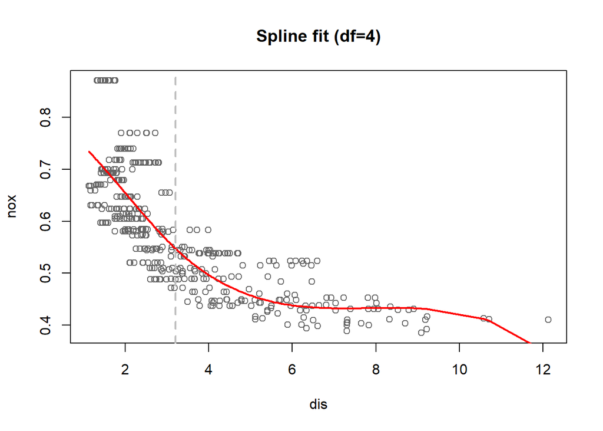

```r
plot(dis,nox, main = "Spline fit (df=4)", col="grey40")
points(points(dis[idx], fitted(bs.fit)[idx], type='l', col=2, lwd=2))
abline(v=attr(bs(dis,df=4), "knots"), lty=2, lwd=2, col="grey")
```

```r
median(dis)
```

```
## [1] 3.20745
```

```r
attr(bs(dis,df=4), "knots")
```

```
##     50%
## 3.20745
```

Without specifying the knot, it was chosen as 4 degree of freedom - 3 = 1 knot. So it is the median of the data,shown above.

### 1.1.5 (e)

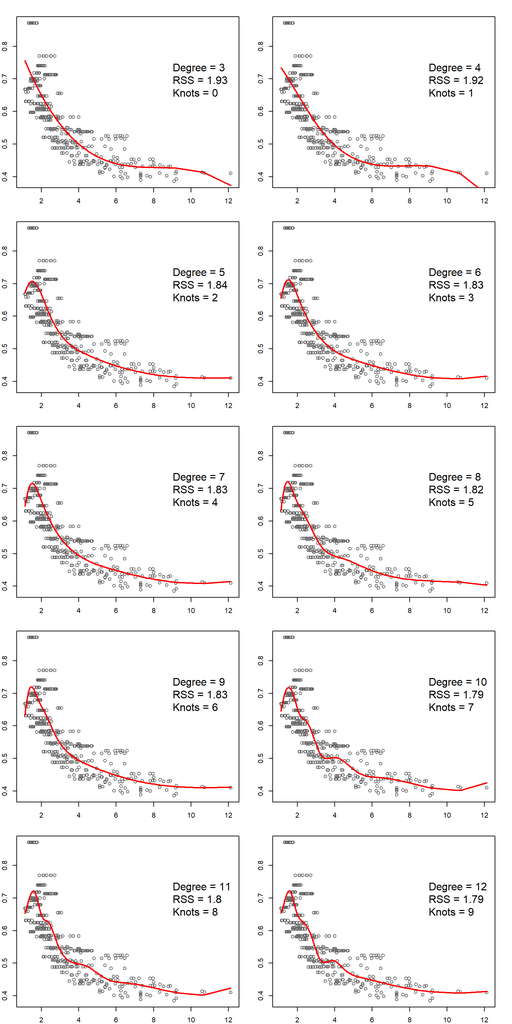

```r
degrees <- 3:12
RSS <- rep(NA,12)

par(mar=c(2,2,2,2))
par(mfrow = c(5, 2))

for(i in degrees){
  fit <- glm(nox ~ bs(dis,df=i),data=Boston)
  RSS[i] <- round(sum(fit$residuals^2),2)
  plot(dis, nox, col="grey40", xlab="nox", ylab="dis")
  legend(8,0.8, paste("Degree = ", i,"\n", "RSS = ", RSS[i],"\n", "Knots = ", i-3, sep=""),bty="n",cex=1.5  )
  points(points(dis[idx], fitted(fit)[idx], type='l', col=2, lwd=2))
}
```

```r
detach(Boston)
```

As the degrees of freedom of the B-splines goes up, the fitted line gets twisting.

### 1.1.6 (f)

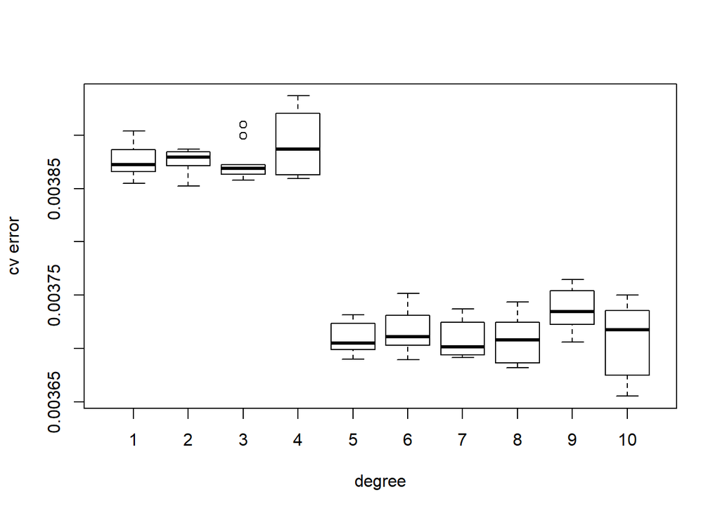

```r
degrees <- 3:12
cv.error10 <- matrix(NA,nrow=10, ncol=10)

for(i in 1:10){
  set.seed(i)
  for (j in degree){
      fit <- glm(nox ~ bs(dis ,j),data=Boston)
      cv.error10[i,j] <- cv.glm(Boston,fit, K=10)$delta[1]
  }
}
boxplot(cv.error10,xlab="degree", ylab="cv error")
```

```r
# Look at the mean of cv error the each degree
round(colMeans(cv.error10),6)
```

```
##  [1] 0.003876 0.003877 0.003874 0.003892 0.003709 0.003717 0.003708
##  [8] 0.003707 0.003737 0.003710
```

# 2 Chapter 8

## 2.1 Question 9

### 2.1.1 (a)

```r
library(tree)
library(rpart)

OJ <- ISLR::OJ

set.seed(666)
trainid <- sample(1:nrow(OJ), size = 800,replace = FALSE)

train <- OJ[trainid,]
test <- OJ[-trainid,]
```

### 2.1.2 (b)

```r
tree1 <- tree(Purchase ~ ., data=OJ)
summary(tree1)
```

```
##
## Classification tree:
## tree(formula = Purchase ~ ., data = OJ)
## Variables actually used in tree construction:
## [1] "LoyalCH"       "PriceDiff"     "ListPriceDiff"
## Number of terminal nodes:  8
## Residual mean deviance:  0.7571 = 804 / 1062
## Misclassification error rate: 0.1636 = 175 / 1070
```

### 2.1.3 (c)

```r
tree1
```

```
## node), split, n, deviance, yval, (yprob)
##       * denotes terminal node
##
##  1) root 1070 1431.00 CH ( 0.61028 0.38972 )
##    2) LoyalCH < 0.5036 469  559.30 MM ( 0.28358 0.71642 )
##      4) LoyalCH < 0.276142 223  164.60 MM ( 0.12108 0.87892 )
##        8) LoyalCH < 0.0356415 75   10.62 MM ( 0.01333 0.98667 ) *
##        9) LoyalCH > 0.0356415 148  137.60 MM ( 0.17568 0.82432 ) *
##      5) LoyalCH > 0.276142 246  336.30 MM ( 0.43089 0.56911 )
##       10) PriceDiff < 0.05 101  105.90 MM ( 0.21782 0.78218 ) *
##       11) PriceDiff > 0.05 145  197.30 CH ( 0.57931 0.42069 ) *
##    3) LoyalCH > 0.5036 601  475.20 CH ( 0.86522 0.13478 )
##      6) LoyalCH < 0.764572 251  289.20 CH ( 0.73705 0.26295 )
##       12) PriceDiff < -0.165 40   48.87 MM ( 0.30000 0.70000 ) *
##       13) PriceDiff > -0.165 211  199.00 CH ( 0.81991 0.18009 )
##         26) ListPriceDiff < 0.135 34   47.02 CH ( 0.52941 0.47059 ) *
##         27) ListPriceDiff > 0.135 177  132.90 CH ( 0.87571 0.12429 ) *
##      7) LoyalCH > 0.764572 350  123.80 CH ( 0.95714 0.04286 ) *
```

Let’s pick the node #27; the asterisk indicates the terminal node. The split criterion is ListPriceDiff > 0.135, the number of observations in that branch is 177 with a deviance of 132.90 and an overall prediction for the branch is CH. About 87.6% of the observations in that branch take the value of CH, and the remaining 12.4% take the value of MM.

### 2.1.4 (d)

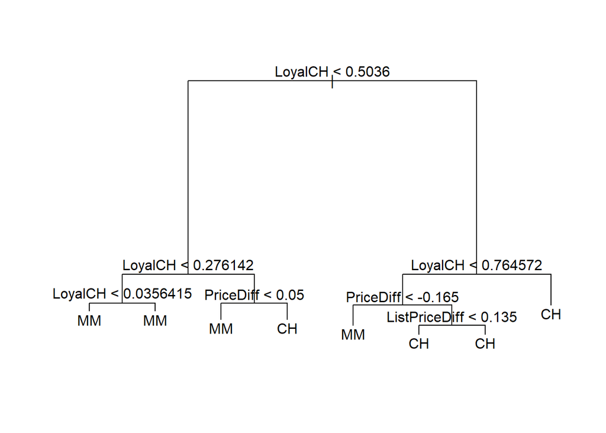

```r
plot(tree1); text(tree1, pretty = 0)
```

It turns out that the most important indicator of outcome variable `Purchase` is `LoyalCH`, since the top three nodes contain `LoyalCH.

### 2.1.5 (e)

```r
preds <- predict(tree1, test, type = "class")
table(preds, test$Purchase)
```

```
##
## preds  CH  MM
##    CH 152  26
##    MM  16  76
```

```r
1 - (152 + 76) / sum(table(preds, test$Purchase))
```

```
## [1] 0.1555556
```

The test error rate is about 15.6%.

### 2.1.6 (f)

```r
set.seed(666)
cv.tree1 <- cv.tree(tree1,FUN=prune.misclass)
cv.tree1
```

```
## $size
## [1] 8 6 4 2 1
##
## $dev
## [1] 183 183 199 227 417
##
## $k
## [1]  -Inf   0.0   8.0  11.5 203.0
##
## $method
## [1] "misclass"
##
## attr(,"class")
## [1] "prune"         "tree.sequence"
```

The $dev index gives the cross-validation error rate. It turns out that both 8 nodes and 6 nodes gave equal cv error of 183.

### 2.1.7 (g)

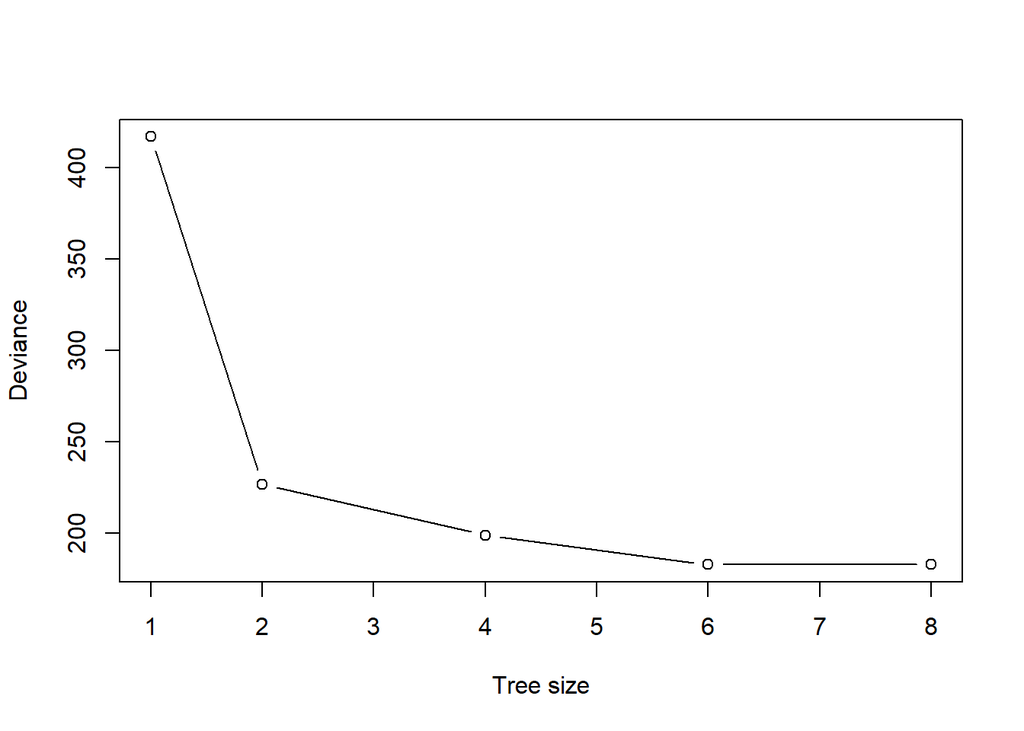

```r
plot(cv.tree1$size, cv.tree1$dev, type = "b", xlab = "Tree size", ylab = "Deviance")
```

It appears that 6-node tree is the smallest tree with the lowest classification error rate.

### 2.1.8 (h)

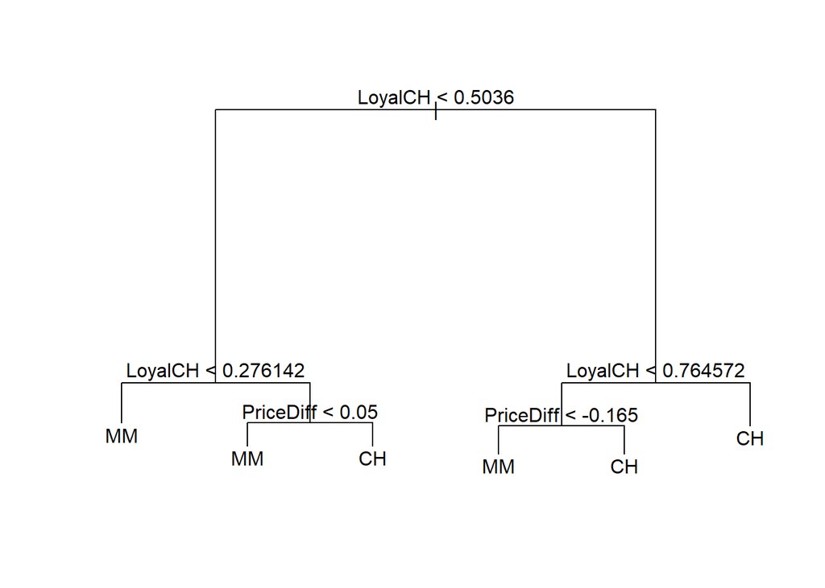

```r
prune1 <- prune.misclass(tree1, best = 6)
plot(prune1);text(prune1)
```

### 2.1.9 (j)

```r
summary(tree1)
```

```
##
## Classification tree:
## tree(formula = Purchase ~ ., data = OJ)
## Variables actually used in tree construction:
## [1] "LoyalCH"       "PriceDiff"     "ListPriceDiff"
## Number of terminal nodes:  8
## Residual mean deviance:  0.7571 = 804 / 1062
## Misclassification error rate: 0.1636 = 175 / 1070
```

```r
summary(prune1)
```

```
##
## Classification tree:
## snip.tree(tree = tree1, nodes = c(4L, 13L))
## Variables actually used in tree construction:
## [1] "LoyalCH"   "PriceDiff"
## Number of terminal nodes:  6
## Residual mean deviance:  0.789 = 839.5 / 1064
## Misclassification error rate: 0.1636 = 175 / 1070
```

In terms of misclassification error rate, the original tree and the pruned tree have same performance. But in terms of residual mean deviance, the tree with slightly more nodes wins over the pruned tree.

### 2.1.10 (k)

```r
prune.preds <- predict(prune1,test, type = "class")
table(prune.preds, test$Purchase)
```

```
##
## prune.preds  CH  MM
##          CH 152  26
##          MM  16  76
```

```r
1 - (152 + 76) / sum(table(preds, test$Purchase))
```

```
## [1] 0.1555556
```

The test error rates for pruned tree is equal to that of the original tree. Actually it is reflected in the cross-validation process.

# 3 Week 9, Khan data

## 3.1 Load data

```r
library(ISLR)
names(Khan)
```

```
## [1] "xtrain" "xtest"  "ytrain" "ytest"
```

```r
train <- data.frame(Khan$xtrain)
train$y <- factor(Khan$ytrain,ordered = FALSE)

test <- data.frame(Khan$xtest)
test$y <- factor(Khan$ytest,ordered = FALSE)

table(train$y)
```

```
##
##  1  2  3  4
##  8 23 12 20
```

```r
table(test$y)
```

```
##
## 1 2 3 4
## 3 6 6 5
```

```r
sum(is.na(train)) # It is a complete dataset
```

```
## [1] 0
```

## 3.2 Fit a random forest model

```r
require(randomForest)

set.seed(666)
rf1 <- randomForest(y ~ ., data=train)
rf1$confusion
```

```
##   1  2  3  4 class.error
## 1 8  0  0  0           0
## 2 0 23  0  0           0
## 3 0  0 12  0           0
## 4 0  0  0 20           0
```

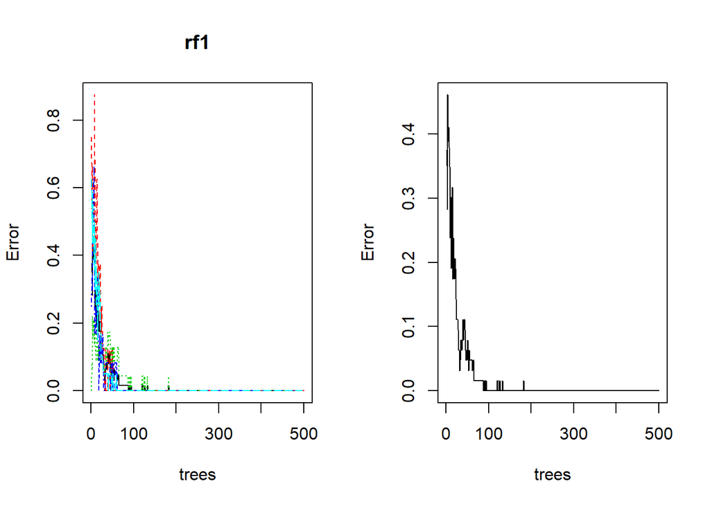

```r
par(mfrow=c(1,2))
plot(rf1) ## OOB + outcomes
plot(rf1$err.rate[,'OOB'], type='l', xlab='trees', ylab='Error') ## overall OOB error only
```

As the bootstrap sample size (ntree) grows over 200, the OOB error rate becomes stable.